# R Commands For MAT121

# 6 Plots

R is powerful and flexible in creating data graphics. Here are the basic graphical commands we are going to use in this class.

- For categorical or discrete numerical data, we use the bar chart and the pie chart to display the distribution associated population from which the data was collected.
- For continuous numerical data, we use the histogram to graphically represent the distribution.
- To see the association between two numerical variables, we can use R command **plot()** to make a scatter plot. We will use this command in this class.

```
hist()                           # histogram
barplot()                        # bar plot for categorical variable
pie()                            # pie chart of a categorical data
boxplot(x,main="title")          # boxplot (box and whiskers)
plot(x)                          # serial plot of numerical data
plot(x,y, xlim=range(-1,1), ylim=range(-1,1), main="title")
                                 # plot the relation between two variables
```

Following a few examples that show you how to use these graphic commands.

- **Example 1** Histogram of the length of CD data

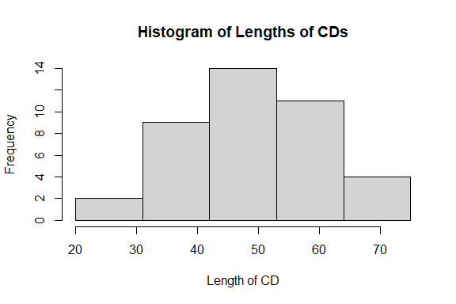

```r
# CAUTION. arguments must be separated by a comma!
hist(x = CD,          # specify the data set
     breaks = bound,  # provide boundary values to define sub-intervals
     main="Histogram of Lengths of CDs",     # add a meaningful title, otherwise
                                             # default title will be automatically added
     xlab = "Length of CD"                   # add a meaningful label to horizontal axis
                                             # otherwise, the data set name will be used.
     )
```

- **Example 2** Course grades data used in the lecture note to create bar chart and pie chart.

```r
grades = c("A", "C", "B", "F", "D", "B", "C", "B", "C", "C", "A", "D", "C", "B", "C", "B", "A", "C", "B", "D")
```

**bar chart** - unlike R command **hist()** that use the original data set and the cut-off boundaries to create a histogram, **barplot()** needs to use the frequency table created based on the original categorical data. The following example shows the steps for creating a bar chart of a given categorical data set.

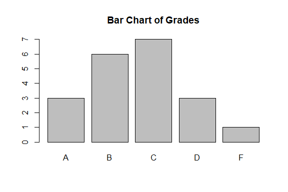

```r
freq.table = table(grades)               # create a frequency table from the categorical data set grades
barplot(freq.table,                      # data set
        main = "Bar Chart of Grades"     # add a meaningful title to the plot
)
```

**Pie Chart** Similar to **barplot()**, **pie()** also requires a frequency table to construct the pie chart of a categorical data set.

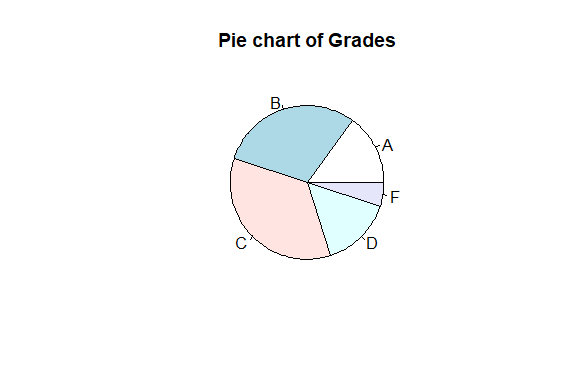

```r
freq.table = table(grades)   # create a frequency table from the categorical data set grades
pie(freq.table, main = "Pie chart of Grades")    # no title will be given by default
```

```r
weight = c(62, 71, 60, 66, 81, 68, 80, 43, 82, 63, 70, 56, 60, 58, 76, 50, 88, 89, 59, 51, 62, 74, 83, 81, 90, 79)
##
height = c(168, 178, 174, 170, 178, 174, 176, 154, 181, 165, 173, 162, 172, 169, 183, 158, 185, 173, 164, 156, 164, 175, 180, 175, 181, 177)
```

The following scatter plot shows the relation between weight and height.

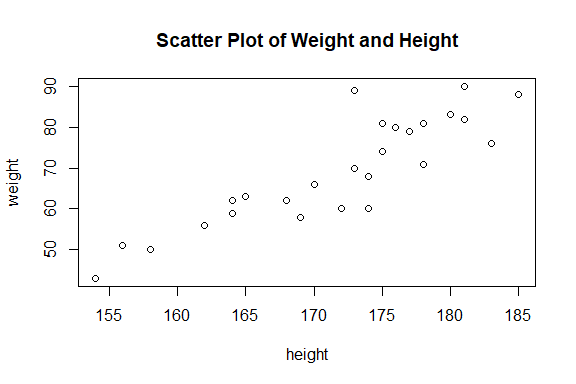

```r
plot(height, weight,
     main = "Scatter Plot of Weight and Height")
```

# 7 standardize data values

The following two commands are used in this course. **scale()** will be used to find the z-scores of a given data set. **round()** is used to round off a given number to keep certain number of decimal places. For a given data set $(x_1, x_2, \cdots, x_n)$, The definition of z-score is given by

$$z_i = \frac{x_i-\bar{x}}{s}$$
where $\bar{x}$ is the mean of the data values and $s$ the standard deviation of the data. The formula are given in the textbook and the lecture note as well.

```
scale()              # converts a data set to standardized scores
round(x,n)           # rounds the values of x to n decimal places
```

- **scale()** - standardization of values of a given data set as shown in the following example.

```r
example.data = c(1, 2, 3, 4, 5, 6, 7)    # Define an example data set
scale(example.data)                      # standardize the values in the data set
```

```
##            [,1]
## [1,] -1.3887301
## [2,] -0.9258201
## [3,] -0.4629100
## [4,]  0.0000000
## [5,]  0.4629100
## [6,]  0.9258201
## [7,]  1.3887301
## attr(,"scaled:center")
## [1] 4
## attr(,"scaled:scale")
## [1] 2.160247
```

- **round(x,n)** rounding off numbers.

```r
round.data = c(2.141587, 2.45356, 4523)   # define a data set with decimals
round(round.data, 3)                   # keep 3 decimal places for all values in the data set
```

```
## [1]    2.142    2.454 4523.000
```

# 8 Statistics and transformations

```
max()
min()
mean()
median()
quantile(x, prob, type = 2)       # quantile/percentile has different definitions.
                                  # In R, function quantile(x, prob, type = 2) use the definition
                                  # given in our lecture note!
sum()         #  sum up all numerical values in the data set
var()         #  produces the variance covariance matrix
sd()          #  standard deviation
fivenum()     #  Tukey fivenumbers min, lowerhinge, median, upperhinge, max.
              #  The type 2 quantile was used in this command.
cumsum(x)     # cumulative sum, etc.
cumprod(x)
## rearrange data values
rev(x)        # reverse the order of values in x
sort(x)       # sort data to ascending (by default)
```

Here are some examples based on data set *weight*.

```r
weight = c(62, 71, 60, 66, 81, 68, 80, 43, 82, 63, 70, 56, 60, 58, 76, 50, 88, 89, 59, 51, 62, 74, 83, 81, 90, 79)
```

- sorting data

```r
sort(weight)
```

```
##  [1] 43 50 51 56 58 59 60 60 62 62 63 66 68 70 71 74 76 79 80 81 81 82 83 88 89
## [26] 90
```

- Minimum and maximum

```r
max(weight)    # 100th quantile
```

```
## [1] 90
```

```r
min(weight)    # 0th quantile
```

```
## [1] 43
```

- summation

```r
sum(weight)
```

```
## [1] 1802
```

- Mean (Average)

```r
mean(weight)
```

```
## [1] 69.30769
```

- Median

```r
median(weight)    # 50th quantile
```

```
## [1] 69
```

- quantile (percentile)

```r
# as an example, we find 35th, 50th (median), 75th quantiles in step
quantile(weight, c(0.35, 0.50, 0.75), type = 2)
```

```
## 35% 50% 75%
##  62  69  81
```

- standard deviation / variance

```r
sd(weight)
```

```
## [1] 12.97619
```

```r
var(weight)
```

```
## [1] 168.3815
```

- Five Number Summary - min, 25th, median, 75th and max.

```r
fivenum(weight)
```

```
## [1] 43 60 69 81 90
```

- Cumulative summation and product - use a small data to illustrate the operation. The cumulative summation will be used in calculating the cumulative frequencies in construct frequency tables.

```r
my.toy.data = c(1,2,3,4,5)    # toy data
```

```r
cumsum(my.toy.data)
```

```
## [1]  1  3  6 10 15
```

```r
cumprod(my.toy.data)
```

```
## [1]   1   2   6  24 120
```

- reverse data values in a data set

```r
rev(my.toy.data)
```

```
## [1] 5 4 3 2 1
```

# 9 Correlation and Regression

We will assess the relationship between two variables such as weight and height of certain population. The following two commands will calculate all quantities we need in this course.

```
cor(x,y,use="pair")    # correlation coefficient
lm(x~y,data=dataset)   # basic least square linear model
```

- Correlation coefficient - a number that reflect the strength of the association of two variables.

```r
cor(height, weight)
```

```
## [1] 0.8768558
```

- Least square regression line

```r
lm(height~weight)
```

```
##
## Call:
## lm(formula = height ~ weight)
##
## Coefficients:
## (Intercept)       weight
##    132.6910       0.5633
```

We can also find other inferential statistics of the least square regression line using the following command

```r
summary(lm(height~weight))
```

```
##
## Call:
## lm(formula = height ~ weight)
##
## Residuals:
##     Min      1Q  Median      3Q     Max
## -9.8231 -2.7379 -0.0289  2.5851  7.5121
##
## Coefficients:
##              Estimate Std. Error t value Pr(>|t|)
## (Intercept) 132.69105    4.44216  29.871  < 2e-16 ***
## weight        0.56328    0.06304   8.935 4.22e-09 ***
## ---
## Signif. codes:  0 '***' 0.001 '**' 0.01 '*' 0.05 '.' 0.1 ' ' 1
##
## Residual standard error: 4.09 on 24 degrees of freedom
## Multiple R-squared:  0.7689, Adjusted R-squared:  0.7592
## F-statistic: 79.84 on 1 and 24 DF,  p-value: 4.223e-09
```

# 10 Tests and confidence interval

```
t.test(x,g)         # one- or two-sample t-test for population mean(s)
prop.test()         # one- or two-sample test for population proportion(s)
pairwise.t.test(x,g)
```

I will update this page with more commands to do confidence intervals and testing hypotheses.